# AED R and Friends: Working with databases using dplyr

## party

```r
library(party)
nla_party <- cforest(chlx_result ~ ., data = nla12_cc[, -1], control = cforest_unbiased(ntree = 1000))
system.time(cforest(chlx_result ~ ., data = nla12_cc[, -1], control = cforest_unbiased(ntree = 1000)))
```

```
##    user  system elapsed
##   4.697   0.037   4.737
```

```r
caret::cforestStats(nla_party)
```

```
##      RMSE  Rsquared
## 0.6108530 0.7767662
```

## ranger

```r
library(ranger)
nla_ranger <- ranger(chlx_result ~ ., data = nla12_cc[, -1], num.trees = 1000,
    mtry = 5, importance = "impurity")
system.time(ranger(chlx_result ~ ., data = nla12_cc[, -1], num.trees = 1000,
    mtry = 5, importance = "impurity"))
```

```
##    user  system elapsed
##   3.839   0.141   0.273
```

```r
nla_ranger
```

```
## Ranger result
##
## Call:
##  ranger(chlx_result ~ ., data = nla12_cc[, -1], num.trees = 1000,      mtry = 5, importance = "impurity")
##
## Type:                             Regression
## Number of trees:                  1000
## Sample size:                      1000
## Number of independent variables:  10
## Mtry:                             5
## Target node size:                 5
## Variable importance mode:         impurity
## OOB prediction error:             0.3387661
## R squared:                        0.7964743
```

```r
ranger::importance(nla_ranger)
```

```
##     area_ha    lat_dd83    lon_dd83    perim_km   elevation turb_result
##    30.24656    37.82495    63.59579    19.45482    51.14400   597.01347
##  doc_result  ntl_result  ptl_result      secchi
##    51.74435   276.55351   173.22574   341.27793
```

# Compare predictions from 2012 models on 2007 data

My understanding of random forests is that separate test and training datasets are not needed to validate the model. The resampling that occurs takes care of this and is another argument in favor of other methods that don’t have this resampling and “out of bag” error built in. That being said, I can see situations where it would be nice to see how well a model predicts an additional, independent dataset. We (finally!!!) can do this with the NLA 2012 and 2007 data.

We will need to build our test dataset and since the `predict()` function is looking for datasets with the same strucutre we will make sure that happens.

## Build test datasets from 2007

```r
wc <- "https://www.epa.gov/sites/production/files/2014-10/nla2007_chemical_conditionestimates_20091123.csv"
sites <- "https://www.epa.gov/sites/production/files/2014-01/nla2007_sampledlakeinformation_20091113.csv"
secchi <- "https://www.epa.gov/sites/production/files/2014-10/nla2007_secchi_20091008.csv"
nla07 <- full_join(read.csv(wc, stringsAsFactors = TRUE), read.csv(sites, stringsAsFactors = TRUE),
    by = c("SITE_ID", "VISIT_NO")) %>% full_join(read.csv(secchi, stringsAsFactors = TRUE),
    by = c("SITE_ID", "VISIT_NO")) %>% filter(VISIT_NO == 1) %>% select(site_id = SITE_ID,
    area_ha = AREA_HA, lat_dd83 = LAT_DD.x, lon_dd83 = LON_DD.x, perim_km = LAKEPERIM,
    elevation = ELEV_PT, turb_result = TURB, doc_result = DOC, ntl_result = NTL,
    ptl_result = PTL, chlx_result = CHLA, secchi = SECMEAN)
nla07_cc <- nla07[complete.cases(nla07[, -1]), ] %>% mutate(ntl_result = log1p(ntl_result),
    ptl_result = log1p(ptl_result), chlx_result = log1p(chlx_result))
tbl_df(nla07_cc)
```

```
## # A tibble: 1,086 × 12
##          site_id    area_ha lat_dd83   lon_dd83  perim_km elevation
##           <fctr>      <dbl>    <dbl>      <dbl>     <dbl>     <dbl>
## 1  NLA06608-0001  66.293055 48.97903 -114.02184  3.178510   1605.73
## 2  NLA06608-0002  14.437998 33.03606  -79.98379  1.743510      4.90
## 3  NLA06608-0003   5.701737 28.04774  -97.85987  1.265008     17.60
## 4  NLA06608-0004  65.386309 37.41662 -108.40458  6.011154   2213.00
## 5  NLA06608-0006  56.199748 41.68315  -73.14652  5.836995    198.75
## 6  NLA06608-0007  25.474763 45.58065  -92.04002  3.022986    390.86
## 7  NLA06608-0008  48.737036 41.29211  -93.59040  5.711381    261.56
## 8  NLA06608-0010  30.037332 42.61823  -83.50589  2.423468    284.65
## 9  NLA06608-0012 177.657513 35.99079  -96.87179 13.506457    255.60
## 10 NLA06608-0013  37.140256 39.97428  -74.56255  8.284688     15.44
## # ... with 1,076 more rows, and 6 more variables: turb_result <dbl>,
## #   doc_result <dbl>, ntl_result <dbl>, ptl_result <dbl>,
## #   chlx_result <dbl>, secchi <dbl>
```

## Predict and compare

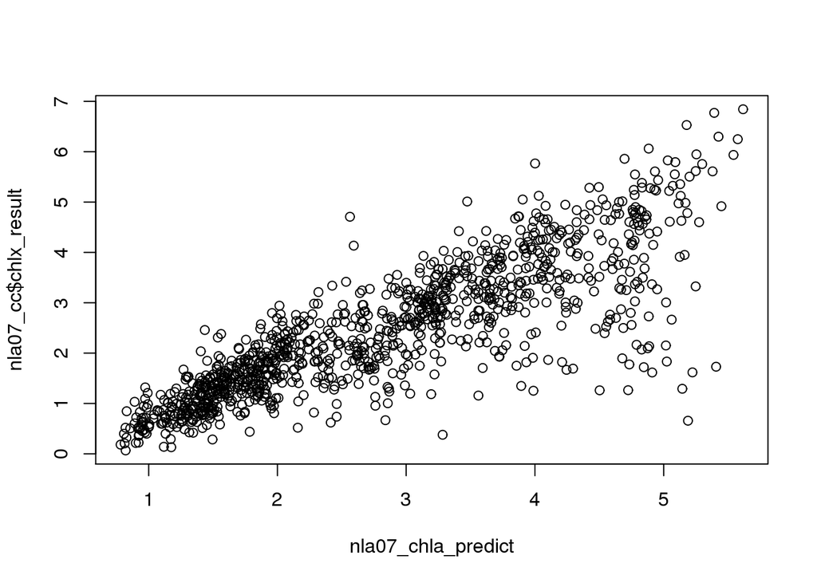

```r
nla07_chla_predict <- predict(object = nla_rf, newdata = nla07_cc)
plot(nla07_chla_predict, nla07_cc$chlx_result)
```